# Generación de paleta de colores a partir de imágenes con técnicas de *machine learning* no supervisado

**Microproyecto 1 — Maestría en Inteligencia Artificial (MLNS)**

**Objetivo:** En este notebook se desarrolla un método basado en técnicas de agrupación no supervisada que permita extraer los sacar los colores dominantes de una imagen que en este caso seran obras de arte y generar un muestrario de colores representativos paara un humano.

En resumen, lo que se hace es:

1. Se eligen 10 imágenes de obras de distintos estilos.
2. Se preparan (redimensionar + convertir a CIELAB) con un pipeline.
3. Se corre K-means en cada imagen, buscando automáticamente cuántos grupos de color (K) tiene sentido usar, con Silhouette Score.
4. Con esos grupos se arma el muestrario final.
5. Se visualiza cómo quedan distribuidos los colores en 2D con t-SNE.

Después de cumplir con estos items el notebook tiene una sección extra (Post-miniproyecto) donde se profundiza un poco más, probando el método en imágenes nuevas y explorando otros criterios.

## 1. Importación de librerías

Se agrupan las librerías por función para mantener el notebook ordenado:

- Datos y archivos: `pandas`, `numpy`, `glob`, `math`, `os`
- Gráficas: `matplotlib.pyplot`, `matplotlib.cm`
- Imágenes: `PIL.Image`
- Color: `skimage.color` (`rgb2lab`, `lab2rgb`)
- Modelo: `KMeans`, `silhouette_score`, `silhouette_samples`, `StandardScaler`
- Pipeline: `Pipeline`, `FunctionTransformer`

```python
# 1. IMPORTAR LIBRERIAS
```

```python
import pandas as pd
```

```python
import numpy as np
```

```python
import matplotlib.pyplot as plt
```

```python
import matplotlib.cm as cm
```

```python
import glob
```

```python
import math
```

```python
import os
```

```python
from sklearn.preprocessing import StandardScaler
```

```python
from sklearn.cluster import KMeans
```

```python
from sklearn.metrics import silhouette_score
```

```python
from PIL import Image
```

```python
from skimage.color import rgb2lab, lab2rgb
```

```python
from sklearn.metrics import silhouette_samples
```

```python
from sklearn.pipeline import Pipeline
```

```python
from sklearn.preprocessing import FunctionTransformer
```

```python
from sklearn.manifold import TSNE
```

```python
from skimage.color import deltaE_ciede2000
```

## 2. Carga de datos

### 2.1 Conjunto de imágenes seleccionado

Se decidió la seleccion un conjunto de **10 obras** que tuvieran una paleta de color variada y una complejidad en su obra diferente, desde cuadros casimonocromáticos (el tenebrismo barroco) hasta pop art con colores planos y saturados, pasando por impresionismo/puntillismo con tonos pastel. La idea era que el método se enfrentara a casos bien distintos de riqueza cromática, para ver si el K se ajustaba bien en cada caso.

| # | Obra | Autor | Estilo / época |
| --- | --- | --- | --- |
| 1 | Autumn Day | Abraham Manievich | Expresionismo |
| 2 | Fumatore | Adriaen Brouwer | Barroco |
| 3 | Lied I | Albert Bloch | Simbolismo |
| 4 | Portrait of Archibald Campbell | Allan Ramsay | Rococó |
| 5 | Frog | Andy Warhol | Pop Art |
| 6 | The Roofs of Paris in the Snow | Auguste Herbin | Puntillismo |
| 7 | Evanescence Red | Denise Green | Minimalismo |
| 8 | St John in the Desert | Domenico Veneziano | Alto Renacimiento |
| 9 | St Jerome | Lorenzo Lotto | Renacimiento temprano |
| 10 | Studio | Pablo Picasso | Cubismo |

```python
# 2. CARGAR DE IMAGENES
```

### 2.2 Búsqueda de las rutas de las imágenes

Se usó `glob` para traer todas las rutas de la carpeta de una sola vez, en vez de escribir cada nombre a mano por si en dado caso decido agregar o quitar una imagen no se debe escribrir mas codigo. `sorted()` lo utilizo para mantner el orden en que llegan las imágenes sin que esto varie.

```python
image_paths = sorted(glob.glob("imagenes-miniproyecto-1/*.jpg"))
```

```python
print(f"Cantidad de paths encontrados: {len(image_paths)}")
```

```
Cantidad de paths encontrados: 10
```

### 2.3 Carga de las imágenes en memoria

Recorro las rutas y abro cada imagen con `PIL.Image`. Fuerzo el modo `"RGB"` en todas, porsi alguna viniera con un canal de transparencia (`RGBA`) u otro formato raro, con esto estandarizo el tipo de imágenes recibidas antes de trabajarlas.

```python
# 2.3 Recorremos los paths y guardamos las imagenes en una variable
```

```python
imagenes = []
```

```python
for path in image_paths:
    img = Image.open(path).convert("RGB")
    imagenes.append(img)
```

```python
print(f"Se cargaron {len(imagenes)} imágenes")
```

```
Se cargaron 10 imágenes
```

### 2.4 Verificación visual del conjunto de imágenes

Revisamos las 10 imágenes en una grilla para confirmar que cargaron bien y que ninguna se ve rara (rotada, con colores raros, etc.). El número de filas se calcula solo a partir de cuántas imágenes hay es decir la grilla se ajusta automáticamente segun las imágenes cargadas.

```python
# 2.4 Calculamos la cantidad de filas y columnas
```

```python
n = len(imagenes)
```

```python
cols = 5
```

```python
rows = math.ceil(n / cols)
```

### 2.5 Función para mostrar la grilla

Se decicidó armar una función para poder visualizar la gilla construida con las imágenes seleccionadas porque se requerirá en los siguientes casos:

- En esta ocasioón para ver las imágenes originales,
- Más adelante (sección 3.5) para ver las redimensionadas, evitando repetir código para las visualizaciones.

```python
# 2.5 Creamos una grilla con subplots para ubicar las imágenes encontradas
```

```python
def mostrar_grilla(lista_imagenes, lista_titulos, titulo_general, cols=5, mostrar_tamano=False):
    """Muestra una lista de imágenes en una grilla, calculando filas automáticamente.
    Si `mostrar_tamano=True`, agrega las dimensiones de cada imagen al título."""
    n = len(lista_imagenes)
    rows = math.ceil(n / cols)

    fig, axes = plt.subplots(rows, cols, figsize=(16, 3.5 * rows))

    for ax, img, titulo in zip(axes.ravel(), lista_imagenes, lista_titulos):
        ax.imshow(img)
        etiqueta = f"{titulo}\n{img.size}" if mostrar_tamano else titulo
        ax.set_title(etiqueta, fontsize=6 if mostrar_tamano else 7)
        ax.axis('off')

    for ax in axes.ravel()[n:]:
        ax.axis('off')

    plt.suptitle(titulo_general, y=1.02)
    plt.tight_layout()
    plt.show()
```

[figure not shown]

```python
nombres = [os.path.basename(p) for p in image_paths]
mostrar_grilla(imagenes, nombres, "Conjunto de imágenes seleccionadas (10 obras, distintos estilos)")
```

### 2.6 Tabla de metadatos

Autor y título los obtengo directamente del nombre de la imagen. El estilo artístico manualmente en un diccionario, porque eso no se puede sacar del nombre del archivo ni de la imagen. Uso diccionario y no una lista en el mismo orden de las imágenes porque si se cambia el orden de los archivos, la lista se desincroniza sin avisar con el diccionario cada estilo siempre va con su archivo correcto.

```python
# 2.6 Se define un arreglo con los estilos de imágenes seleccionadas
```

```python
estilo_por_archivo = {
    "abraham-manievich_autumn-day.jpg": "Expresionismo",
    "adriaen-brouwer_fumatore.jpg": "Barroco",
    "albert-bloch_lied-i-1914.jpg": "Simbolismo",
    "allan-ramsay_portrait-of-archibald-campbell-3rd-duke-of-argyll-1.jpg": "Rococó",
    "andy-warhol_frog.jpg": "Pop Art",
    "auguste-herbin_the-roofs-of-paris-in-the-snow-1902.jpg": "Puntillismo",
    "denise-green_evanescence-red-2007.jpg": "Minimalismo",
    "domenico-veneziano_st-john-in-the-desert.jpg": "Alto Renacimiento",
    "lorenzo-lotto_st-jerome.jpg": "Renacimiento temprano",
    "pablo-picasso_studio.jpg": "Cubismo",
}
```

Se hace la función `parsear_nombre_archivo` para sacar autor y título del nombre del archivo, y los uso junto con el diccionario `estilo_por_archivo` para armar el DataFrame de metadatos. Si algún archivo no está en ese diccionario, la columna `estilo` queda con el valor **PENDIENTE**, en vez de fallar o de asignar algo incorrecto.

```python
def parsear_nombre_archivo(nombre_archivo):
    """Extrae autor y título directamente del nombre del archivo
    (convención: autor-slug_titulo-slug.jpg)."""
    base = os.path.splitext(nombre_archivo)[0]
    partes = base.split("_", 1)
    autor = partes[0].replace("-", " ").title()
        # ojo: .title() deja cosas raras tipo "3Rd" en vez de "3rd" en un archivo
    # (el del Duque de Argyll), no lo arreglé porque solo pasaba en ese caso
    titulo = partes[1].replace("-", " ").title() if len(partes) > 1 else "Sin título"
    return autor, titulo

filas = []
for archivo in [os.path.basename(p) for p in image_paths]:
    autor, titulo = parsear_nombre_archivo(archivo)
    estilo = estilo_por_archivo.get(archivo, "PENDIENTE")
    filas.append({"archivo": archivo, "titulo": titulo, "autor": autor, "estilo": estilo})

metadatos = pd.DataFrame(filas)
metadatos
```

|  | archivo | titulo | autor | estilo |
| --- | --- | --- | --- | --- |
| 0 | abraham-manievich_autumn-day.jpg | Autumn Day | Abraham Manievich | Expresionismo |
| 1 | adriaen-brouwer_fumatore.jpg | Fumatore | Adriaen Brouwer | Barroco |
| 2 | albert-bloch_lied-i-1914.jpg | Lied I 1914 | Albert Bloch | Simbolismo |
| 3 | allan-ramsay_portrait-of-archibald-campbell-3r... | Portrait Of Archibald Campbell 3Rd Duke Of Arg... | Allan Ramsay | Rococó |
| 4 | andy-warhol_frog.jpg | Frog | Andy Warhol | Pop Art |
| 5 | auguste-herbin_the-roofs-of-paris-in-the-snow-... | The Roofs Of Paris In The Snow 1902 | Auguste Herbin | Puntillismo |
| 6 | denise-green_evanescence-red-2007.jpg | Evanescence Red 2007 | Denise Green | Minimalismo |
| 7 | domenico-veneziano_st-john-in-the-desert.jpg | St John In The Desert | Domenico Veneziano | Alto Renacimiento |
| 8 | lorenzo-lotto_st-jerome.jpg | St Jerome | Lorenzo Lotto | Renacimiento temprano |
| 9 | pablo-picasso_studio.jpg | Studio | Pablo Picasso | Cubismo |

## 3. Redimensionado de imágenes

### 3.1 Justificación

Las imágenes originales son grandes (tienen un tamaño aprox. 1300×1600 px, más de 2 millones de píxeles), y cada píxel termina siendo una observación para el modelo. Procesarlas a ese tamaño completo sería costoso/lento, sobre todo para t-SNE (complejidad cuadrática). Por eso se redimensiona cada imagen a un **lado máximo de 150 px**, reduciendo el volumen de datos sin afectar la distribución de colores dominantes.

Redimensionar **conservando la proporción original**: el lado más largo queda en 150 px y el otro se ajusta proporcionalmente, sin deformar ni recortar nada. Como consecuencia, el tamaño final varía según la relación de aspecto de cada imagen esto no afecta el pipeline, ya que cada imagen se procesa de forma independiente.

### 3.2 Prueba con una imagen

Antes de aplicar el redimensionado a las 10 imágenes, se valida el procedimiento sobre una sola imagen de referencia.

```
Tamaño original: (2188, 1382)
Modo: RGB
```

[figure not shown]

```python
img_prueba = Image.open(image_paths[9]).convert("RGB")
print("Tamaño original:", img_prueba.size)
print("Modo:", img_prueba.mode)

plt.imshow(img_prueba)
plt.axis('off')
plt.title("Imagen original (sin redimensionar)")
plt.show()
```

```python
def redimensionar_proporcional(img, lado_max=150):
    """Redimensiona una imagen para que su lado más largo mida `lado_max` px,
    conservando la proporción original (sin deformar, sin recortar,
    sin agregar píxeles de relleno)."""
    # antes probaba con resize 150,150 fijo, pero deformaba las imágenes
    # que no eran cuadradas, por eso el cálculo de proporción de acá abajo
    ancho_original, alto_original = img.size

    if ancho_original >= alto_original:
        nuevo_ancho = lado_max
        nuevo_alto = int(alto_original * (lado_max / ancho_original))
    else:
        nuevo_alto = lado_max
        nuevo_ancho = int(ancho_original * (lado_max / alto_original))

    return img.resize((nuevo_ancho, nuevo_alto), Image.LANCZOS)
```

### 3.3 Validación del resultado

```
Tamaño original: (2188, 1382)
Tamaño nuevo: (150, 94)
```

[figure not shown]

```python
img_resized = redimensionar_proporcional(img_prueba, lado_max=150)

print("Tamaño original:", img_prueba.size)
print("Tamaño nuevo:", img_resized.size)

plt.imshow(img_resized)
plt.axis('off')
plt.title("Imagen redimensionada (proporción conservada)")
plt.show()
```

### 3.4 Generalización a las 10 imágenes

Luego deber la función implementada en una imagen de muestra, aplico a las 10 el mismo proceso y guardo el resultado en una lista nueva (`imagenes_resized`) sin tocar `imagenes`, que la dejo intacta por si la necesito más adelante en su tamaño original.

```python
imagenes_resized = [redimensionar_proporcional(img, lado_max=150) for img in imagenes]

for path, img_r in zip(image_paths, imagenes_resized):
    print(f"{os.path.basename(path):<55} -> {img_r.size}")
```

```
abraham-manievich_autumn-day.jpg                        -> (150, 104)
adriaen-brouwer_fumatore.jpg                            -> (113, 150)
albert-bloch_lied-i-1914.jpg                            -> (135, 150)
allan-ramsay_portrait-of-archibald-campbell-3rd-duke-of-argyll-1.jpg -> (119, 150)
andy-warhol_frog.jpg                                    -> (149, 150)
auguste-herbin_the-roofs-of-paris-in-the-snow-1902.jpg  -> (136, 150)
denise-green_evanescence-red-2007.jpg                   -> (150, 76)
domenico-veneziano_st-john-in-the-desert.jpg            -> (150, 131)
lorenzo-lotto_st-jerome.jpg                             -> (122, 150)
pablo-picasso_studio.jpg                                -> (150, 94)
```

### 3.5 Verificación visual de las imágenes redimensionadas

Se muestran las 10 imágenes ya redimensionadas, confirmando visualmente que ninguna se ve deformada respecto a la original, cada una conserva su proporción es decir solo cambia su tamaño.

[figure not shown]

```python
mostrar_grilla(imagenes_resized, nombres, "Imágenes redimensionadas (proporción conservada)", mostrar_tamano=True)
```

## 4. Conversión de espacio de color (RGB a CIELAB)

### 4.1 Justificación

RGB es lo que usa la pantalla para mostrar colores, pero no sirve mucho para comparar qué tan parecidos son dos colores para el ojo. Y eso me importa acá: el resultado final son paletas de color para personas, así que las diferencias entre colores tienen que significar algo perceptualmente, no solo numéricamente.El problema con RGB es simple: dos colores pueden estar "cerca" en números y verse totalmente distintos, o al revés. No es confiable para esto.

Por eso uso CIELAB (LAB), está pensado para acercarse más a cómo el ojo realmente ve lasdiferencias de color. Tiene sentido acá porque quien va a usar estas paletas al final es una persona (un diseñador, un artista), no otro algoritmo.

### 4.2 Función de conversión

SE define la función `convertir_a_lab` y esta toma la imagen ya redimensionada, la normaliza a [0,1] (rgb2lab lo necesita así, no en 0-255 si no divido, calcula colores que no existen, sin marcar error), la convierte a LAB, y aplana el resultado a una tabla de píxeles (n_píxeles, 3), que es lo que después va a recibir K-means.

```python
def convertir_a_lab(img):
    """Convierte una imagen PIL (RGB) a un array de píxeles en espacio CIELAB.
    Devuelve una matriz de forma (n_píxeles, 3)."""
    rgb_array = np.asarray(img) / 255.0
    lab_array = rgb2lab(rgb_array)
    return lab_array.reshape(-1, 3)
```

```python
# Nota: los pixeles vienen en 0-255, pero rgb2lab trabaja en escala [0,1]
#       si no divido entre 255 antes de convertir, el resultado sale mal,
#       porque no estaría en la escala esperada y podría terminar
#       calculando colores que no existen en la escala de color que necesita rgb2lab
```

### 4.3 Pipeline de transformación

Se encadena el resize y la conversión a LAB en un solo objeto `Pipeline`, usando `FunctionTransformer` para envolver las funciones que ya tenía. esto no cambia la logica de las funciones, solo agrupa en un solo paso, y así queda más explícito el uso de estas funciones.

```python
pipeline_preparacion = Pipeline([
    ("resize", FunctionTransformer(lambda img: redimensionar_proporcional(img, lado_max=150))),
    ("a_lab", FunctionTransformer(convertir_a_lab)),
])
```

### 4.4 Prueba con una imagen

Se valida el pipeline sobre la imagen de referencia `img_prueba`, antes de generalizarloa las 10 imágenes. El pipeline aplica internamente el redimensionado y la conversión a CIELAB en una sola llamada.

```python
pixels_lab_prueba = pipeline_preparacion.transform(img_prueba)

print("Forma de la matriz LAB:", pixels_lab_prueba.shape)
print("Rango de L (luminosidad):", pixels_lab_prueba[:,0].min().round(1), "-", pixels_lab_prueba[:,0].max().round(1))
print("Rango de a:", pixels_lab_prueba[:,1].min().round(1), "-", pixels_lab_prueba[:,1].max().round(1))
print("Rango de b:", pixels_lab_prueba[:,2].min().round(1), "-", pixels_lab_prueba[:,2].max().round(1))
```

```
Forma de la matriz LAB: (14100, 3)
Rango de L (luminosidad): 0.0 - 100.0
Rango de a: -28.7 - 70.0
Rango de b: -11.5 - 75.2
```

### 4.5 Inspección de los datos como tabla

Para facilitar la lectura de los valores obtenidos, se envuelve la matriz LABen un `DataFrame` con nombres de columna.

```python
df_pixeles = pd.DataFrame(pixels_lab_prueba, columns=["L", "A", "B"])
print(df_pixeles.shape)
df_pixeles.describe()
```

```
(14100, 3)
```

|  | L | A | B |
| --- | --- | --- | --- |
| count | 14100.000000 | 14100.000000 | 14100.000000 |
| mean | 60.858263 | 4.915199 | 22.737449 |
| std | 29.502990 | 18.536377 | 27.930221 |
| min | 0.000000 | -28.728615 | -11.478930 |
| 25% | 40.347259 | -3.624409 | -0.696098 |
| 50% | 72.624646 | -1.231644 | 7.641466 |
| 75% | 85.694886 | 1.922201 | 57.662579 |
| max | 99.950448 | 69.967744 | 75.239758 |

**Lectura rápida de los estadísticos para la imagen de prueba:**

### 4.6 Generalización a las 10 imágenes

Se aplica el pipeline `pipeline_preparacion` directamente a las 10 imágenes originales `imagenes`, guardando el resultado en una lista `pixels_lab_todas` una matriz de píxeles LAB por cada imagen del conjunto. El pipeline se encarga del redimensionado y la conversión a CIELAB en un solo paso.

```python
pixels_lab_todas = [pipeline_preparacion.transform(img) for img in imagenes]

for nombre, pixels in zip(nombres, pixels_lab_todas):
    print(f"{nombre:<65} -- {pixels.shape[0]:>6} píxeles LAB")
```

```
abraham-manievich_autumn-day.jpg                                  --  15600 píxeles LAB
adriaen-brouwer_fumatore.jpg                                      --  16950 píxeles LAB
albert-bloch_lied-i-1914.jpg                                      --  20250 píxeles LAB
allan-ramsay_portrait-of-archibald-campbell-3rd-duke-of-argyll-1.jpg --  17850 píxeles LAB
andy-warhol_frog.jpg                                              --  22350 píxeles LAB
auguste-herbin_the-roofs-of-paris-in-the-snow-1902.jpg            --  20400 píxeles LAB
denise-green_evanescence-red-2007.jpg                             --  11400 píxeles LAB
domenico-veneziano_st-john-in-the-desert.jpg                      --  19650 píxeles LAB
lorenzo-lotto_st-jerome.jpg                                       --  18300 píxeles LAB
pablo-picasso_studio.jpg                                          --  14100 píxeles LAB
```

## 5. Modelo de agrupación (K-means + búsqueda de K)

### 5.1 Justificación

En esta sección usaremos K-means. Se eligen centroides como representación de cada grupo porque buscamos resumir los colores de la imagen sin necesidad de que el color representativo sea exactamente uno de los píxeles originales. Además, las imágenes tienen una cantidad considerable de píxeles, por lo que K-means resulta conveniente para trabajar con estos datos.

No se toma únicamente el mayor Silhouette, ya que puede aparecer un cluster muy pequeño formado por píxeles atípicos. Para evitar esto, se descartan los valores de K en los que el cluster más pequeño tenga menos del 2 % de los píxeles. Después de aplicar este filtro se selecciona el K con mayor Silhouette.

También se utiliza `n_init=10` para realizar varias inicializaciones de K-means y reducir la dependencia del resultado respecto a una única inicialización.

### 5.1.1 Un caso que motiva ajustar el criterio

Antes de definir la función final veremos un hallazgo concreto que nos lleva a incorporar una regla de desempate. Al revisar la imagen de San Jerónimo como caso de ejemplo, se observó que el color rojo de la túnica "visualmente muy significativo" no aparecía en la paleta generada con K=4. Calculando el Silhouette Score para cada K por separado en esta imagen:

```python
idx_lotto = nombres.index("lorenzo-lotto_st-jerome.jpg")
pixels_lotto = pixels_lab_todas[idx_lotto]

n = pixels_lotto.shape[0]
rs = np.random.RandomState(10)
idx_sample = rs.choice(n, size=min(4000, n), replace=False)
sample = pixels_lotto[idx_sample]

scores_ejemplo = []
for k in range(4, 8):
    km = KMeans(n_clusters=k, n_init=10, random_state=10)
    km.fit(pixels_lotto)
    labels_sample = km.predict(sample)
    score = silhouette_score(sample, labels_sample)
    scores_ejemplo.append((k, score))
    print(f"K={k}  silhouette={score:.3f}")
```

```
K=4  silhouette=0.551
K=5  silhouette=0.543
K=6  silhouette=0.511
K=7  silhouette=0.498
```

La diferencia entre K=4 (0.551) y K=5 (0.543) es de apenas **0.008** prácticamente un empate estadístico. Sin embargo, el color rojo de la túnica solo aparece como cluster propio a partir de K=5:

```python
km4 = KMeans(n_clusters=4, n_init=10, random_state=10).fit(pixels_lotto)
km5 = KMeans(n_clusters=5, n_init=10, random_state=10).fit(pixels_lotto)

for k, modelo in [(4, km4), (5, km5)]:
    centroides_rgb = np.clip(lab2rgb(modelo.cluster_centers_.reshape(-1,1,3)).reshape(-1,3), 0, 1)
    print(f"\nColores con K={k}:")
    for c in (centroides_rgb * 255).astype(int):
        print(f"  RGB{tuple(c)}")
```

```
Colores con K=4:
  RGB(np.int64(112), np.int64(76), np.int64(51))
  RGB(np.int64(195), np.int64(199), np.int64(212))
  RGB(np.int64(38), np.int64(45), np.int64(45))
  RGB(np.int64(179), np.int64(139), np.int64(89))

Colores con K=5:
  RGB(np.int64(35), np.int64(43), np.int64(45))
  RGB(np.int64(178), np.int64(139), np.int64(89))
  RGB(np.int64(195), np.int64(199), np.int64(213))
  RGB(np.int64(98), np.int64(76), np.int64(53))
  RGB(np.int64(139), np.int64(69), np.int64(47))
```

### 5.2 Función de búsqueda del K óptimo

```python
def buscar_mejor_k(pixels_lab, k_range=range(4, 10), sample_size=4000, seed=10, tolerancia=0.01):
    """Busca el número óptimo de clusters K para una imagen, usando Silhouette Score.
    El score se calcula sobre una submuestra de píxeles por eficiencia (silhouette
    es O(n^2)). Se descartan K con clusters muy pequeños (< 2% de los píxeles).
    Entre los K cuyo score esté dentro de `tolerancia` del mejor score encontrado, se
    prefiere el K más alto."""
    # empecé con k_range=range(2,11), pero en obras oscuras daba paletas de 2 colores
    # nada más, así que subí el mínimo a 4
    n = pixels_lab.shape[0]
    rs = np.random.RandomState(seed)
    idx_sample = rs.choice(n, size=min(sample_size, n), replace=False)
    sample = pixels_lab[idx_sample]
    resultados = []
    for k in k_range:
        km = KMeans(n_clusters=k, n_init=10, random_state=seed)
        labels_full = km.fit_predict(pixels_lab)
        labels_sample = km.predict(sample)
        score = silhouette_score(sample, labels_sample)
        _, counts = np.unique(labels_full, return_counts=True)
        prop_min = counts.min() / n
        resultados.append({"k": k, "score": score, "prop_min_cluster": prop_min,
                            "modelo": km, "labels": labels_full})
    # el filtro de 2% lo bajé de 3% porque con 3% se me perdían colores válidos
    # en un par de imágenes (lo vi comparando con Fumatore)
    validos = [r for r in resultados if r["prop_min_cluster"] >= 0.02]
    candidatos = validos if validos else resultados

    mejor_score = max(r["score"] for r in candidatos)
    empatados = [r for r in candidatos if mejor_score - r["score"] <= tolerancia]
    mejor = max(empatados, key=lambda r: r["k"])
    return mejor, resultados
```

Sobre los valores por defecto:

```python
mejor, resultados_k = buscar_mejor_k(pixels_lab_prueba)

print(f"K óptimo seleccionado: {mejor['k']}")
print(f"Silhouette score: {mejor['score']:.3f}")
for r in resultados_k:
    print(f"  K={r['k']:>2}  silhouette={r['score']:.3f}  cluster_min={r['prop_min_cluster']*100:.1f}%")
```

```
K óptimo seleccionado: 8
Silhouette score: 0.667
  K= 4  silhouette=0.662  cluster_min=10.4%
  K= 5  silhouette=0.675  cluster_min=10.5%
  K= 6  silhouette=0.663  cluster_min=6.6%
  K= 7  silhouette=0.658  cluster_min=4.6%
  K= 8  silhouette=0.667  cluster_min=3.3%
  K= 9  silhouette=0.653  cluster_min=3.2%
```

### 5.3 Prueba con una imagen

Se implementa la función sobre `pixels_lab_prueba` con la imagen de referencia usada en la sección 4, `pablo-picasso_studio.jpg`, antes de generalizarla a las 10 imágenes.

```python
def graficar_silhouette_detallado(pixels_lab, modelo):
    """Gráfica de silhouette por muestra, para un modelo ya entrenado (análisis
    exploratorio, no forma parte del criterio automático de selección de K)."""
    labels = modelo.labels_
    k = modelo.n_clusters
    valores = silhouette_samples(pixels_lab, labels)

    fig, ax = plt.subplots(figsize=(8, 5))
    y_lower = 10
    for i in range(k):
        valores_i = np.sort(valores[labels == i])
        y_upper = y_lower + len(valores_i)
        color = cm.nipy_spectral(i / k)
        ax.fill_betweenx(np.arange(y_lower, y_upper), 0, valores_i, facecolor=color, alpha=0.7)
        ax.text(-0.05, y_lower + 0.5 * len(valores_i), str(i))
        y_lower = y_upper + 10

    ax.axvline(valores.mean(), color="red", linestyle="--", label=f"Promedio = {valores.mean():.3f}")
    ax.set_title(f"Silhouette detallado (K={k})")
    ax.set_xlabel("Coeficiente de silhouette")
    ax.set_yticks([])
    ax.legend()
    plt.show()
```

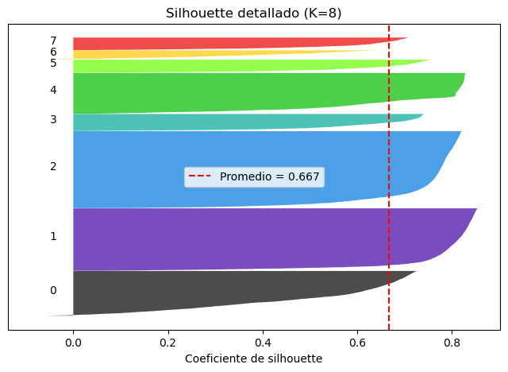

```python
graficar_silhouette_detallado(pixels_lab_prueba, mejor["modelo"])
```

### 5.4 Generalización a las 10 imágenes

Se aplica la función `buscar_mejor_k()` a cada una de las 10 imágenes, usando `pixels_lab_todas`. Luego se guarda el modelo y el K óptimo de cada una en un diccionario indexado por nombre de archivo. Esto confirma si K varía según la imagen, tal como exige el enunciado.

```python
resultados_por_imagen = {}

for nombre, pixels in zip(nombres, pixels_lab_todas):
    mejor_k, _ = buscar_mejor_k(pixels)
    resultados_por_imagen[nombre] = mejor_k
    print(f"{nombre:<65} K = {mejor_k['k']}   silhouette = {mejor_k['score']:.3f}")
```

```
abraham-manievich_autumn-day.jpg                                  K = 5   silhouette = 0.360
adriaen-brouwer_fumatore.jpg                                      K = 4   silhouette = 0.455
albert-bloch_lied-i-1914.jpg                                      K = 4   silhouette = 0.398
allan-ramsay_portrait-of-archibald-campbell-3rd-duke-of-argyll-1.jpg K = 4   silhouette = 0.760
andy-warhol_frog.jpg                                              K = 8   silhouette = 0.637
auguste-herbin_the-roofs-of-paris-in-the-snow-1902.jpg            K = 4   silhouette = 0.514
denise-green_evanescence-red-2007.jpg                             K = 4   silhouette = 0.752
domenico-veneziano_st-john-in-the-desert.jpg                      K = 4   silhouette = 0.497
lorenzo-lotto_st-jerome.jpg                                       K = 5   silhouette = 0.543
pablo-picasso_studio.jpg                                          K = 8   silhouette = 0.667
```

### 5.6 Variación entre imágenes

Se observa que el valor de `K` **varía entre imágenes** (rango 4 a 8 en mi conjunto) es decir no es un valor fijo, confirmando que el número de grupos se ajusta a la complejidad cromática de cada obra con paletas más contrastantes tienden a un `K` más alto, mientras que imágenes con paletas más uniformes u oscuras convergen a un `K` menor.

## 6. Muestrario de colores

### 6.1 Justificación

Los centroides que entrega K-means están en espacio LAB, así que primero debemos convertirlos de vuelta a RGB para poder mostrarlos como colores reales. Además, en vez de dejarlos en el orden que los entrega K-means los ordenamos por luminosidad (de más claro a más oscuro) esto es lo que hace que el muestrario se vea "diseñado" y no aleatorio, similar a cómo se presentan las paletas en herramientas como Adobe Color.

El ancho de cada franja de color en el muestrario es proporcional a qué tan dominante es ese color en la imagen (proporción de píxeles asignados a ese cluster), para que la paleta refleje no solo qué colores hay, sino también cuánto peso visual tiene cada uno.

### 6.2 Función de generación del muestrario

```python
def generar_muestrario(modelo, pixels_lab):
    """Convierte los centroides (LAB) a RGB y los ordena por luminosidad.
    Devuelve los colores RGB y la proporción de píxeles de cada uno."""
    centroides_lab = modelo.cluster_centers_
    centroides_rgb = lab2rgb(centroides_lab.reshape(-1, 1, 3)).reshape(-1, 3)
    centroides_rgb = np.clip(centroides_rgb, 0, 1)

    labels = modelo.labels_
    _, counts = np.unique(labels, return_counts=True)
    proporciones = counts / counts.sum()

    orden = np.argsort(-centroides_lab[:, 0])  # de más claro a más oscuro
    return centroides_rgb[orden], proporciones[orden]
```

### 6.3 Función para dibujar el muestrario

Dibujamos el muestrario como franjas horizontales, una junto a otra, con el ancho de cada franja proporcional a qué tan dominante es ese color.

```python
def dibujar_muestrario(colores_rgb, proporciones, titulo=""):
    """Dibuja el muestrario como franjas horizontales, con ancho proporcional
    a la dominancia de cada color."""
    fig, ax = plt.subplots(figsize=(8, 1.5))
    left = 0
    for color, prop in zip(colores_rgb, proporciones):
        ax.barh(0, prop, left=left, color=color, height=1, edgecolor='white', linewidth=1.5)
        left += prop
    ax.set_xlim(0, 1)
    ax.set_ylim(-0.5, 0.5)
    ax.axis('off')
    ax.set_title(titulo)
    plt.show()
```

### 6.4 Prueba con una imagen

```python
colores_prueba, proporciones_prueba = generar_muestrario(mejor["modelo"], pixels_lab_prueba)
```

```
RGB(np.int64(212), np.int64(216), np.int64(213))  ->  27.8% de la imagen
RGB(np.int64(238), np.int64(214), np.int64(87))  ->  22.5% de la imagen
RGB(np.int64(226), np.int64(147), np.int64(43))  ->  4.7% de la imagen
RGB(np.int64(160), np.int64(137), np.int64(72))  ->  3.3% de la imagen
RGB(np.int64(109), np.int64(103), np.int64(97))  ->  16.2% de la imagen
RGB(np.int64(200), np.int64(38), np.int64(44))  ->  6.1% de la imagen
RGB(np.int64(137), np.int64(32), np.int64(40))  ->  4.6% de la imagen
RGB(np.int64(21), np.int64(24), np.int64(25))  ->  14.8% de la imagen
```

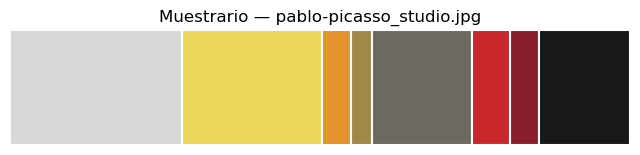

```python
for color, prop in zip(colores_prueba, proporciones_prueba):
    rgb255 = (color * 255).astype(int)
    print(f"RGB{tuple(rgb255)}  ->  {prop*100:.1f}% de la imagen")

dibujar_muestrario(colores_prueba, proporciones_prueba, titulo="Muestrario — pablo-picasso_studio.jpg")
```

```python
def rgb_a_cmyk(rgb):
    """Convierte un color RGB (0-1) a su aproximación CMYK (0-1),
    la proporción de tinta usada en impresión para reproducir ese color."""
    r, g, b = rgb
    k = 1 - max(r, g, b)
    if k == 1:
        return 0.0, 0.0, 0.0, 1.0
    c = (1 - r - k) / (1 - k)
    m = (1 - g - k) / (1 - k)
    y = (1 - b - k) / (1 - k)
    return c, m, y, k
```

```
RGB(np.int64(212), np.int64(216), np.int64(213))  |  CMYK(2%, 0%, 1%, 15%)  ->  27.8% de la imagen
RGB(np.int64(238), np.int64(214), np.int64(87))  |  CMYK(0%, 10%, 63%, 7%)  ->  22.5% de la imagen
RGB(np.int64(226), np.int64(147), np.int64(43))  |  CMYK(0%, 35%, 81%, 11%)  ->  4.7% de la imagen
RGB(np.int64(160), np.int64(137), np.int64(72))  |  CMYK(0%, 14%, 55%, 37%)  ->  3.3% de la imagen
RGB(np.int64(109), np.int64(103), np.int64(97))  |  CMYK(0%, 5%, 11%, 57%)  ->  16.2% de la imagen
RGB(np.int64(200), np.int64(38), np.int64(44))  |  CMYK(0%, 81%, 78%, 22%)  ->  6.1% de la imagen
RGB(np.int64(137), np.int64(32), np.int64(40))  |  CMYK(0%, 76%, 70%, 46%)  ->  4.6% de la imagen
RGB(np.int64(21), np.int64(24), np.int64(25))  |  CMYK(13%, 4%, 0%, 90%)  ->  14.8% de la imagen
```

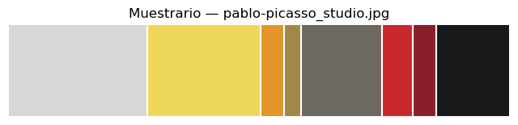

```python
colores_prueba, proporciones_prueba = generar_muestrario(mejor["modelo"], pixels_lab_prueba)

for color, prop in zip(colores_prueba, proporciones_prueba):
    rgb255 = (color * 255).astype(int)
    c, m, y, k = rgb_a_cmyk(color)
    print(f"RGB{tuple(rgb255)}  |  CMYK({c*100:.0f}%, {m*100:.0f}%, {y*100:.0f}%, {k*100:.0f}%)  ->  {prop*100:.1f}% de la imagen")

dibujar_muestrario(colores_prueba, proporciones_prueba, titulo="Muestrario — pablo-picasso_studio.jpg")
```

```python
colores_prueba, proporciones_prueba = generar_muestrario(mejor["modelo"], pixels_lab_prueba)

filas = []
for color, prop in zip(colores_prueba, proporciones_prueba):
    rgb255 = tuple((color * 255).astype(int))
    c, m, y, k = rgb_a_cmyk(color)
    filas.append({
        "RGB": rgb255,
        "C%": round(c*100, 1),
        "M%": round(m*100, 1),
        "Y%": round(y*100, 1),
        "K%": round(k*100, 1),
        "Proporción en la imagen": f"{prop*100:.1f}%"
    })

df_muestrario = pd.DataFrame(filas)
df_muestrario
```

|  | RGB | C% | M% | Y% | K% | Proporción en la imagen |
| --- | --- | --- | --- | --- | --- | --- |
| 0 | (212, 216, 213) | 1.7 | 0.0 | 1.3 | 15.2 | 27.8% |
| 1 | (238, 214, 87) | 0.0 | 9.8 | 63.2 | 6.5 | 22.5% |
| 2 | (226, 147, 43) | 0.0 | 34.8 | 81.0 | 11.1 | 4.7% |
| 3 | (160, 137, 72) | 0.0 | 14.3 | 55.0 | 37.1 | 3.3% |
| 4 | (109, 103, 97) | 0.0 | 4.9 | 10.6 | 57.2 | 16.2% |
| 5 | (200, 38, 44) | 0.0 | 80.6 | 78.0 | 21.6 | 6.1% |
| 6 | (137, 32, 40) | 0.0 | 76.4 | 70.3 | 46.2 | 4.6% |
| 7 | (21, 24, 25) | 13.0 | 3.7 | 0.0 | 90.1 | 14.8% |

### 6.5 Generalización a las 10 imágenes

Aplicamos `generar_muestrario()` a las 10 imágenes, usando el modelo ya entrenado de cada una que esta guardado en `resultados_por_imagen` y luego las muestro todas juntas.

[figure not shown]

```python
fig, axes = plt.subplots(len(nombres), 1, figsize=(8, 1.3 * len(nombres)))
for ax, nombre in zip(axes, nombres):
    modelo = resultados_por_imagen[nombre]["modelo"]
    pixels = pixels_lab_todas[nombres.index(nombre)]
    colores, proporciones = generar_muestrario(modelo, pixels)

    left = 0
    for color, prop in zip(colores, proporciones):
        ax.barh(0, prop, left=left, color=color, height=1, edgecolor='white', linewidth=1.5)
        left += prop
    ax.set_xlim(0, 1)
    ax.set_ylim(-0.5, 0.5)
    ax.axis('off')
    k = resultados_por_imagen[nombre]["k"]
    ax.set_title(f"{nombre}  (K={k})", fontsize=8, loc='left')
plt.tight_layout()
plt.show()
```

## 6.6 Tabla combinada: metadatos y paleta de colores

Junto los metadatos (autor, título, estilo) con la paleta de cada obra en una sola tabla, una fila por imagen. Los colores, su versión en CMYK y las proporciones quedan como listas dentro de cada celda, porque cada obra tiene un número distinto de colores según su K.

```python
filas_por_obra = []
```

```python
for nombre in nombres:
    modelo = resultados_por_imagen[nombre]["modelo"]
    pixels = pixels_lab_todas[nombres.index(nombre)]
    colores, proporciones = generar_muestrario(modelo, pixels)

    autor, titulo = parsear_nombre_archivo(nombre)
    estilo = estilo_por_archivo.get(nombre, "PENDIENTE")

    rgb_list = [tuple((c * 255).astype(int)) for c in colores]
    cmyk_list = [tuple(round(v*100, 1) for v in rgb_a_cmyk(c)) for c in colores]
    prop_list = [round(p*100, 1) for p in proporciones]

    filas_por_obra.append({
        "archivo": nombre,
        "titulo": titulo,
        "autor": autor,
        "estilo": estilo,
        "k": resultados_por_imagen[nombre]["k"],
        "paleta_rgb": rgb_list,
        "paleta_cmyk": cmyk_list,
        "proporciones_%": prop_list,
    })
```

```python
tabla_paletas = pd.DataFrame(filas_por_obra)
tabla_paletas
```

|  | archivo | titulo | autor | estilo | k | paleta_rgb | paleta_cmyk | proporciones_% |
| --- | --- | --- | --- | --- | --- | --- | --- | --- |
| 0 | abraham-manievich_autumn-day.jpg | Autumn Day | Abraham Manievich | Expresionismo | 5 | [(165, 182, 163), (186, 159, 116), (159, 92, 6... | [(9.1, 0.0, 10.3, 28.6), (0.0, 14.2, 37.4, 26.... | [20.5, 13.1, 17.4, 25.5, 23.5] |
| 1 | adriaen-brouwer_fumatore.jpg | Fumatore | Adriaen Brouwer | Barroco | 4 | [(171, 144, 106), (113, 93, 71), (73, 62, 53),... | [(0.0, 15.7, 38.1, 32.6), (0.0, 17.8, 37.1, 55... | [6.0, 8.9, 31.4, 53.7] |
| 2 | albert-bloch_lied-i-1914.jpg | Lied I 1914 | Albert Bloch | Simbolismo | 4 | [(185, 143, 119), (162, 147, 153), (186, 78, 6... | [(0.0, 23.0, 35.8, 27.1), (0.0, 9.5, 5.6, 36.2... | [15.4, 30.5, 11.6, 42.5] |
| 3 | allan-ramsay_portrait-of-archibald-campbell-3r... | Portrait Of Archibald Campbell 3Rd Duke Of Arg... | Allan Ramsay | Rococó | 4 | [(184, 156, 114), (99, 77, 53), (110, 36, 24),... | [(0.0, 15.2, 38.0, 27.5), (0.0, 22.2, 45.6, 61... | [10.4, 9.8, 3.0, 76.8] |
| 4 | andy-warhol_frog.jpg | Frog | Andy Warhol | Pop Art | 8 | [(189, 164, 58), (157, 165, 144), (87, 154, 58... | [(0.0, 12.8, 68.9, 25.8), (4.8, 0.0, 12.9, 35.... | [3.6, 8.2, 5.3, 2.5, 8.2, 15.3, 6.2, 50.7] |
| 5 | auguste-herbin_the-roofs-of-paris-in-the-snow-... | The Roofs Of Paris In The Snow 1902 | Auguste Herbin | Puntillismo | 4 | [(176, 186, 181), (116, 135, 145), (105, 121, ... | [(5.6, 0.0, 2.7, 26.8), (20.4, 7.2, 0.0, 42.8)... | [48.4, 28.6, 13.8, 9.2] |
| 6 | denise-green_evanescence-red-2007.jpg | Evanescence Red 2007 | Denise Green | Minimalismo | 4 | [(231, 223, 201), (240, 214, 90), (227, 124, 6... | [(0.0, 3.4, 12.9, 9.2), (0.0, 10.9, 62.6, 5.6)... | [4.0, 5.1, 4.7, 86.2] |
| 7 | domenico-veneziano_st-john-in-the-desert.jpg | St John In The Desert | Domenico Veneziano | Alto Renacimiento | 4 | [(200, 187, 175), (119, 128, 151), (133, 113, ... | [(0.0, 6.7, 12.6, 21.3), (21.3, 15.4, 0.0, 40.... | [44.0, 9.2, 29.2, 17.7] |
| 8 | lorenzo-lotto_st-jerome.jpg | St Jerome | Lorenzo Lotto | Renacimiento temprano | 5 | [(195, 199, 213), (178, 139, 89), (139, 69, 47... | [(8.3, 6.4, 0.0, 16.4), (0.0, 22.0, 50.0, 30.1... | [15.8, 19.5, 6.7, 19.7, 38.4] |
| 9 | pablo-picasso_studio.jpg | Studio | Pablo Picasso | Cubismo | 8 | [(212, 216, 213), (238, 214, 87), (226, 147, 4... | [(1.7, 0.0, 1.3, 15.2), (0.0, 9.8, 63.2, 6.5),... | [27.8, 22.5, 4.7, 3.3, 16.2, 6.1, 4.6, 14.8] |

## 7. Visualización de la distribución de colores (t-SNE)

### 7.1 Justificación

Para En este caso que estamos trabajando se omite el PCA previo: los píxeles ya están representados en solo 3 dimensiones (L, A, B), por lo que no hay ruido de alta dimensionalidad que reducir aplicar PCA sobre un espacio ya de 3 dimensiones no aportaría beneficio.

Se aplica t-SNE directamente sobre una muestra de los píxeles LAB, coloreando cada punto con su color real (convertido de vuelta a RGB) en lugar de con marcadores por clase en este problema no hay clases discretas, así que el color real de cada punto cumple un rol informativo.

### 7.2 Función de visualización

```python
def visualizar_tsne(pixels_lab, sample_size=2000, perplexity=30, seed=0):
    """Reduce una muestra de píxeles LAB a 2D con t-SNE, para visualizar
    la distribución de colores de la imagen."""
    n = pixels_lab.shape[0]
    rs = np.random.RandomState(seed)
    idx = rs.choice(n, size=min(sample_size, n), replace=False)

    tsne = TSNE(n_components=2, perplexity=perplexity, random_state=seed, verbose=0)
    emb = tsne.fit_transform(pixels_lab[idx])
    colores_pixel = np.clip(lab2rgb(pixels_lab[idx].reshape(-1, 1, 3)).reshape(-1, 3), 0, 1)

    return emb, colores_pixel
```

## 7.3 Prueba con perplexity por defecto (30)

Continuo con las pruebas con una imagen antes de generalizar a las 10 siempre analizando antes de implementar en todo el grupo por si algo falla, es más fácil detectar en cuál paso fue.

Uso `perplexity=30` porque con mis 2000 píxeles de muestra es un valor razonable: la recomendación general es que la perplexity sea bastante menor que el número de puntos (típicamente entre 5 y 50), así que con 2000 muestras, 30 vecinos por punto es una proporción chica que permite ver estructura local sin volverse inestable. Además es el valor por defecto de sklearn, antes de comparar con perplexity más bajo en la sección 7.4.

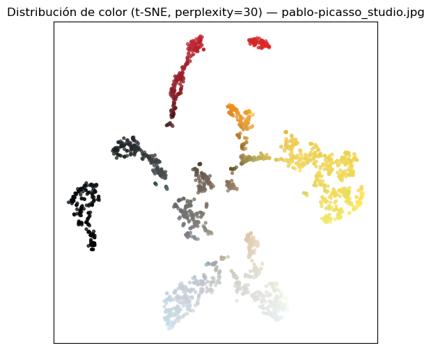

```python
emb_prueba, colores_pixel_prueba = visualizar_tsne(pixels_lab_prueba, perplexity=30)

plt.figure(figsize=(6, 6))
plt.title("Distribución de color (t-SNE, perplexity=30) — pablo-picasso_studio.jpg")
plt.scatter(emb_prueba[:, 0], emb_prueba[:, 1], c=colores_pixel_prueba, s=8, alpha=0.7)
plt.xticks([])
plt.yticks([])
plt.show()
```

## 7.4 Exploración con perplexity distinto

Se explora el efecto de reducir `perplexity` de 30 a 5. Este parámetro controla cuántos vecinos cercanos considera t-SNE al construir la representación valores bajos tienden a formar grupos más pequeños y locales, mientras que valores altos capturan mejor la estructura global.

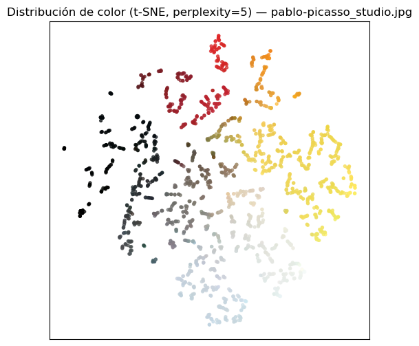

```python
emb_p5, colores_pixel_p5 = visualizar_tsne(pixels_lab_prueba, perplexity=5)

plt.figure(figsize=(6, 6))
plt.title("Distribución de color (t-SNE, perplexity=5) — pablo-picasso_studio.jpg")
plt.scatter(emb_p5[:, 0], emb_p5[:, 1], c=colores_pixel_p5, s=8, alpha=0.7)
plt.xticks([])
plt.yticks([])
plt.show()
```

## 7.5 Generalización a las 10 imágenes

Se aplica `visualizar_tsne()` con `perplexity=30` (valor por defecto, adecuado para el tamaño de muestra usado) a cada imagen del conjunto, guardando el resultado para la sección de resultados finales.

```python
tsne_por_imagen = {}
```

```python
for nombre, pixels in zip(nombres, pixels_lab_todas):
    emb, colores_pixel = visualizar_tsne(pixels, perplexity=30)
    tsne_por_imagen[nombre] = {"emb": emb, "colores": colores_pixel}
```

```python
print(f"t-SNE calculado para {len(tsne_por_imagen)} imágenes")
```

```
t-SNE calculado para 10 imágenes
```

## 8. Resultados finales consolidados

Antes se reconstruía la imagen usando la misma versión de 150px con la que entrené el modelo, pero esto hacia que se veriera muy pixelada, no porque faltaran colores, sino porque la imagen en sí era pequeña. La solución implementada fue entrenar sobre 150px (rápido), pero para el caso de la reconstrucción final usar una versión más grande se decidió subir a 800px, prediciendo el cluster de cada píxel con el modelo ya entrenado. Como `predict()` es mucho más barato que `fit()`, esto no afecta el tiempo de entrenamiento, solo mejora cómo se ve el resultado.

```python
def reconstruir_imagen_alta_resolucion(modelo, img_original, lado_max=800):
    """Ahora recibe el modelo directamente, en vez de buscarlo en
    resultados_por_imagen — así funciona también para imágenes nuevas,
    fuera del conjunto de las 10 originales."""
    img_grande = redimensionar_proporcional(img_original, lado_max=lado_max)
    pixels_lab_grande = convertir_a_lab(img_grande)
    labels_grande = modelo.predict(pixels_lab_grande)

    centroides_lab = modelo.cluster_centers_
    centroides_rgb = lab2rgb(centroides_lab.reshape(-1, 1, 3)).reshape(-1, 3)
    centroides_rgb = np.clip(centroides_rgb, 0, 1)

    ancho, alto = img_grande.size
    return centroides_rgb[labels_grande].reshape(alto, ancho, 3)
```

[figure not shown]

```python
fig = plt.figure(figsize=(18, 4 * len(nombres)))

for i, nombre in enumerate(nombres):
    modelo = resultados_por_imagen[nombre]["modelo"]
    k = resultados_por_imagen[nombre]["k"]
    idx_imagen = nombres.index(nombre)
    pixels = pixels_lab_todas[idx_imagen]
    colores, proporciones = generar_muestrario(modelo, pixels)

    autor_obra, titulo_obra = parsear_nombre_archivo(nombre)
    emb = tsne_por_imagen[nombre]["emb"]
    colores_pixel = tsne_por_imagen[nombre]["colores"]
    img_reconstruida = reconstruir_imagen_alta_resolucion(modelo, imagenes[idx_imagen], lado_max=800)

    # (a) Imagen original
    ax0 = fig.add_subplot(len(nombres), 4, i*4 + 1)
    ax0.imshow(imagenes_resized[idx_imagen])
    ax0.set_title(f"{titulo_obra} — {autor_obra}", fontsize=9)
    ax0.axis('off')

    # (b) Imagen reconstruida con la paleta
    ax1 = fig.add_subplot(len(nombres), 4, i*4 + 2)
    ax1.imshow(img_reconstruida)
    ax1.set_title(f"Reconstruida (K={k})", fontsize=9)
    ax1.axis('off')

    # (c) Muestrario de colores
    ax2 = fig.add_subplot(len(nombres), 4, i*4 + 3)
    left = 0
    for color, prop in zip(colores, proporciones):
        ax2.barh(0, prop, left=left, color=color, height=1, edgecolor='white', linewidth=1.5)
        left += prop
    ax2.set_xlim(0, 1)
    ax2.set_ylim(-0.5, 0.5)
    ax2.axis('off')
    ax2.set_title("Paleta", fontsize=9)

    # (d) Distribución t-SNE
    ax3 = fig.add_subplot(len(nombres), 4, i*4 + 4)
    ax3.scatter(emb[:, 0], emb[:, 1], c=colores_pixel, s=6, alpha=0.7)
    ax3.set_title("Distribución (t-SNE)", fontsize=9)
    ax3.set_xticks([])
    ax3.set_yticks([])

plt.tight_layout()
plt.show()
```

### 8.1 Discusión final

En un inicio de la creación de este proyecto el K utilizado como piso fue 2, pero esto no fue la mejor opción por esto se cambia el piso y se establese el K en 4 y como se ve en los resultados de las imágenes el K termina variando entre imágenes (4 a 8 en mi conjunto final, después de subir el piso mínimo a 4 y agregar la tolerancia de desempate) confirma que el número de grupos se ajusta según la complejidad cromática de cada obra, no es un valor fijo.

La reconstrucción se calcula sobre una versión de mayor resolución (800px) que la usada para entrenar (150px), para que no se vea pixelada sin perder velocidad de cómputo.

La visualización t-SNE confirma que los colores parecidos quedan agrupados en el espacio 2D, lo que valida que trabajar en LAB produce agrupaciones que tienen sentido con cómo percibimos el color.

### 8.2 Evaluación cuantitativa de la reconstrucción

Anteriormente hicimos una reconstrucción donde la imagen se ve parecida a la original, pero esa no seria una forma correcta de justificar el resultado ya que puede ser meramente perceptual. Para respaldarlo con un número, se mide el error perceptual (ΔE CIEDE2000) entre cada píxel original y el color de su centroide asignado. Esto da una idea objetiva de qué tan fiel es la paleta reducida a la imagen real, más allá de la impresión visual.

```python
def evaluar_reconstruccion(modelo, pixels_lab):
    """Calcula el error perceptual (ΔE00) entre cada píxel original y el
    color de su centroide asignado, para evaluar qué tan fiel es la
    reconstrucción a la imagen real."""
    labels = modelo.labels_
    centroides_lab = modelo.cluster_centers_
    pixels_reconstruidos = centroides_lab[labels]

    delta_e00 = deltaE_ciede2000(
        pixels_lab.reshape(-1, 1, 3),
        pixels_reconstruidos.reshape(-1, 1, 3)
    ).reshape(-1)

    return {
        "media": np.mean(delta_e00),
        "mediana": np.median(delta_e00),
        "p95": np.percentile(delta_e00, 95),
        "delta_e00": delta_e00,
    }
```

#### 8.2.1 Prueba con imagen de referencia

```python
resultado_reconstruccion = evaluar_reconstruccion(mejor["modelo"], pixels_lab_prueba)

print(f"ΔE00 medio: {resultado_reconstruccion['media']:.3f}")
print(f"ΔE00 mediana: {resultado_reconstruccion['mediana']:.3f}")
print(f"ΔE00 p95: {resultado_reconstruccion['p95']:.3f}")
```

```
ΔE00 medio: 5.617
ΔE00 mediana: 4.723
ΔE00 p95: 13.484
```

```python
# Nota: se usa ΔE CIEDE2000 en vez de la distancia euclidiana simple en LAB que usa K-means
#       internamente (y que se usó en la sección de discriminabilidad). Ambas trabajan sobre el
#       mismo espacio de color LAB, pero ΔE00 corrige distorsiones conocidas de la distancia
#       euclidiana simple, dando una medida más precisa de fidelidad perceptual relevante aquí
#       porque el objetivo es medir qué tan bien se ve la reconstrucción para un humano, no solo
#       la calidad matemática del clustering.
```

#### 8.2.2 porcentaje de píxeles por debajo de distintos umbrales

```python
for umbral in [1, 2, 3, 5, 10]:
    porcentaje = np.mean(resultado_reconstruccion["delta_e00"] <= umbral) * 100
    print(f"ΔE00 ≤ {umbral:2d}: {porcentaje:6.2f}%")
```

```
ΔE00 ≤  1:   4.90%
ΔE00 ≤  2:  14.90%
ΔE00 ≤  3:  24.87%
ΔE00 ≤  5:  53.30%
ΔE00 ≤ 10:  86.98%
```

#### 8.2.3 histograma visual

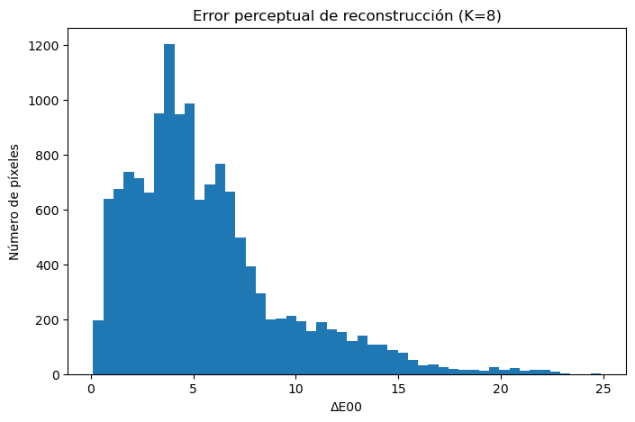

```python
plt.figure(figsize=(8, 5))
plt.hist(resultado_reconstruccion["delta_e00"], bins=50)
plt.xlabel("ΔE00")
plt.ylabel("Número de píxeles")
plt.title(f"Error perceptual de reconstrucción (K={mejor['k']})")
plt.show()
```

#### 8.2.4 generalización a las 10 imágenes

```python
resultados_reconstruccion = []

for nombre in nombres:
    modelo = resultados_por_imagen[nombre]["modelo"]
    pixels = pixels_lab_todas[nombres.index(nombre)]
    resultado = evaluar_reconstruccion(modelo, pixels)

    autor, titulo = parsear_nombre_archivo(nombre)
    resultados_reconstruccion.append({
        "titulo": titulo,
        "k": resultados_por_imagen[nombre]["k"],
        "deltaE_media": round(resultado["media"], 2),
        "deltaE_p95": round(resultado["p95"], 2),
    })

df_reconstruccion = pd.DataFrame(resultados_reconstruccion)
df_reconstruccion.sort_values("deltaE_media")
```

|  | titulo | k | deltaE_media | deltaE_p95 |
| --- | --- | --- | --- | --- |
| 1 | Fumatore | 4 | 3.05 | 6.91 |
| 6 | Evanescence Red 2007 | 4 | 3.08 | 8.43 |
| 3 | Portrait Of Archibald Campbell 3Rd Duke Of Arg... | 4 | 4.32 | 12.22 |
| 9 | Studio | 8 | 5.62 | 13.48 |
| 5 | The Roofs Of Paris In The Snow 1902 | 4 | 6.12 | 12.07 |
| 4 | Frog | 8 | 6.19 | 14.68 |
| 8 | St Jerome | 5 | 7.17 | 15.52 |
| 7 | St John In The Desert | 4 | 7.85 | 14.99 |
| 0 | Autumn Day | 5 | 8.76 | 15.36 |
| 2 | Lied I 1914 | 4 | 9.12 | 15.73 |

#### 8.2.5 Conlusion de metricas de reconstrucción

El error de reconstrucción no depende solo de K. esto se puede observar en la tabla para los casos de Fumatore y Evanescence Red donde un K=4 aparentemente menor que otros casos logran los errores más bajos 3.05 y 3.08 porque sus zonas de color son grandes y uniformes.

Autumn Day y Lied I, con K similar o menor, tienen los errores más altos 8.76 y 9.12 porque las formas y brochazos presentes en la obra generan variación tonal dentro de una misma zona, que un solo centroide no puede capturar bien. Lo que nos deja como conclusión que la fidelidad no es solo cuántos colores tiene la paleta, sino qué tan homogéneas son las regiones de color de la obra.

## 9. Función integradora

Se combina todo el pipeline (preparación, búsqueda de K, muestrario, reconstrucción, t-SNE) en una única función que recibe solo una ruta de imagen y devuelve todos los resultados. Esta función **no reimplementa lógica**: reutiliza exactamente las funciones ya definidas y justificadas en las secciones 4 a 8, solo las encadena.

### 9.1 Pipeline para extraer paleta

Esta función reutiliza el mismo `pipeline_preparacion` que se armo para la sección, junto con `buscar_mejor_k`, `generar_muestrario` y otras funciones. Eso con el fin de mantener el mismo patrón de ir agrupando funciones ya explicadas en una sola que luego pueda ejecutar de forma mas simple para procesar otras imágenes ya en producción.

```python
def extraer_paleta(image_path, lado_reconstruccion=800):
    """Pipeline completo: de una ruta de imagen a todos los resultados del método.
    Internamente reutiliza pipeline_preparacion, buscar_mejor_k, generar_muestrario,
    reconstruir_imagen_alta_resolucion y visualizar_tsne — ya definidas y validadas
    individualmente en las secciones anteriores."""
    img_original = Image.open(image_path).convert("RGB")

    # Preparación (sección 4.3)
    pixels_lab = pipeline_preparacion.transform(img_original)

    # Búsqueda de K (sección 5.2)
    mejor_k, resultados_k = buscar_mejor_k(pixels_lab)

    # Muestrario (sección 6.2)
    colores_rgb, proporciones = generar_muestrario(mejor_k["modelo"], pixels_lab)

    # Reconstrucción en alta resolución (sección 8.0)
    img_reconstruida = reconstruir_imagen_alta_resolucion(
        mejor_k["modelo"], img_original, lado_max=lado_reconstruccion
    )
    # t-SNE (sección 7.2)
    emb, colores_pixel = visualizar_tsne(pixels_lab)

    return {
        "archivo": os.path.basename(image_path),
        "pixels_lab": pixels_lab,
        "modelo": mejor_k["modelo"],
        "k": mejor_k["k"],
        "silhouette": mejor_k["score"],
        "colores_rgb": colores_rgb,
        "proporciones": proporciones,
        "img_reconstruida": img_reconstruida,
        "tsne_emb": emb,
        "tsne_colores": colores_pixel,
    }
```

```python
image_paths_nuevas = sorted(glob.glob("imagenes-miniproyecto-1/Nuevas-imagenes-entrenamiento/*.jpg"))
print(f"Cantidad de imágenes nuevas encontradas: {len(image_paths_nuevas)}")
for p in image_paths_nuevas:
    print(p)
```

```
Cantidad de imágenes nuevas encontradas: 3
imagenes-miniproyecto-1/Nuevas-imagenes-entrenamiento\andrea-del-verrocchio_the-baptism-of-christ.jpg
imagenes-miniproyecto-1/Nuevas-imagenes-entrenamiento\andrea-mantegna_the-house-of-ludovico-gonzaga-bridegroom-decorated-wall-and-his-son-1475.jpg
imagenes-miniproyecto-1/Nuevas-imagenes-entrenamiento\benozzo-gozzoli_dream-of-innocent-iii-and-the-confirmation-of-the-rule-detail.jpg
```

```python
resultados_nuevos = {}
```

```python
for path in image_paths_nuevas:
    resultado = extraer_paleta(path)
    resultados_nuevos[os.path.basename(path)] = resultado
    print(f"{os.path.basename(path)}: K={resultado['k']}, silhouette={resultado['silhouette']:.3f}")
```

```
andrea-del-verrocchio_the-baptism-of-christ.jpg: K=5, silhouette=0.473
andrea-mantegna_the-house-of-ludovico-gonzaga-bridegroom-decorated-wall-and-his-son-1475.jpg: K=5, silhouette=0.409
benozzo-gozzoli_dream-of-innocent-iii-and-the-confirmation-of-the-rule-detail.jpg: K=8, silhouette=0.364
```

### 9.2 visualizar estos resultados

[figure not shown]

```python
fig = plt.figure(figsize=(18, 4 * len(resultados_nuevos)))

for i, (archivo, resultado) in enumerate(resultados_nuevos.items()):
    img_original = Image.open([p for p in image_paths_nuevas if archivo in p][0]).convert("RGB")
    img_original_resized = redimensionar_proporcional(img_original, lado_max=500)

    ax0 = fig.add_subplot(len(resultados_nuevos), 4, i*4 + 1)
    ax0.imshow(img_original_resized)
    ax0.set_title(archivo[:40], fontsize=8)
    ax0.axis('off')

    ax1 = fig.add_subplot(len(resultados_nuevos), 4, i*4 + 2)
    ax1.imshow(resultado["img_reconstruida"])
    ax1.set_title(f"Reconstruida (K={resultado['k']})", fontsize=9)
    ax1.axis('off')

    ax2 = fig.add_subplot(len(resultados_nuevos), 4, i*4 + 3)
    left = 0
    for color, prop in zip(resultado["colores_rgb"], resultado["proporciones"]):
        ax2.barh(0, prop, left=left, color=color, height=1, edgecolor='white', linewidth=1.5)
        left += prop
    ax2.set_xlim(0, 1)
    ax2.set_ylim(-0.5, 0.5)
    ax2.axis('off')
    ax2.set_title("Paleta", fontsize=9)

    ax3 = fig.add_subplot(len(resultados_nuevos), 4, i*4 + 4)
    ax3.scatter(resultado["tsne_emb"][:, 0], resultado["tsne_emb"][:, 1],
                c=resultado["tsne_colores"], s=6, alpha=0.7)
    ax3.set_title("Distribución (t-SNE)", fontsize=9)
    ax3.set_xticks([])
    ax3.set_yticks([])

plt.tight_layout()
plt.show()
```

## 10. Post-miniproyecto

### 10.1 Justificación

### 10.2 Armonía de color **modelo de Itten**

Durante todo el proyecto hemos estado buscando la paleta de color mas representativa de las imagenes que venimos seleccionando pero en este punto cambiaremos un poco la pregunta objetivo por "¿esos colores combinan bien entre sí?" que es justo lo que un profesional del diseño o simplemente alguien que necesita tomar una descisión mas asistida para poder usar esa paleta tal cual, o si le conviene ajustarla. Esta sección explora esa segunda pregunta.

#### 10.2.1 Evaluando armonía con el modelo de Itten

Existe en diseño la teoría del color `modelo de Itten` que dice que la combinación de colores sulen verse bien juntos, segun que tan sepaprados estan de la rueda de corolo, para entender un poco esto podemos dar el siguiente ejemplo:

- Los complementarios son colores opuestos como rojo y verde, los análogos son colores parecidos entre sí como azul y azul-verdoso, y las tríadas son tres colores repartidos de forma pareja alrededor de la rueda.

Para ver si la paleta de una obra sigue alguno de estos patrones de color, se calcula en que punto de la rueda cromática esta cada tono, esto se puede hacer usando los valores de `a` y `b` del modelo usado **LAB** y comparar esas posiciones entre todos los colores de la paleta contra los patrones clásicos.

```python
def calcular_hue_lab(lab_color):
    """Calcula el ángulo de tono (hue, en grados 0-360) a partir de los canales
    a y b de un color en LAB. Es la misma idea que el 'hue' de HSV, pero
    calculado sobre el espacio perceptual LAB en vez de RGB."""
    L, a, b = lab_color
    hue = np.degrees(np.arctan2(b, a)) % 360
    return hue
```

```python
PLANTILLAS_ARMONIA = {
    "complementaria": [180],
    "analoga": [30],
    "triada": [120, 240],
    "tetrada": [90, 180, 270],
}

def evaluar_armonia(centroides_lab):
    """Calcula, para cada par de colores de la paleta, la diferencia de hue,
    y mide qué tan cerca está esa diferencia de alguna plantilla clásica de
    armonía. Devuelve la plantilla más cercana y qué tan bien encaja (0 = encaja
    perfecto, valores más altos = menos armonioso según la teoría)."""
    hues = [calcular_hue_lab(c) for c in centroides_lab]
    n = len(hues)

    diferencias = []
    for i in range(n):
        for j in range(i+1, n):
            diff = abs(hues[i] - hues[j])
            diff = min(diff, 360 - diff)  # distancia circular
            diferencias.append(diff)

    mejor_plantilla, menor_error = None, float("inf")
    for nombre, angulos_objetivo in PLANTILLAS_ARMONIA.items():
        errores = [min(abs(d - ang) for ang in angulos_objetivo) for d in diferencias]
        error_promedio = np.mean(errores)
        if error_promedio < menor_error:
            menor_error = error_promedio
            mejor_plantilla = nombre

    return mejor_plantilla, menor_error
```

```python
centroides_lab_prueba = mejor["modelo"].cluster_centers_
plantilla, error = evaluar_armonia(centroides_lab_prueba)
print(f"Plantilla de armonía más cercana: {plantilla}")
print(f"Error promedio respecto a esa plantilla: {error:.1f}°")
```

```
Plantilla de armonía más cercana: tetrada
Error promedio respecto a esa plantilla: 41.5°
```

Con K=8, el error respecto a la mejor plantilla (tetrada) es alto (41.5°) peor no necesariamente es algo malo, pasemos a interpretarlo: Las plantillas clásicas de armonía se diseñaron para paletas de 2 a 4 colores, no para las 28 relaciones posibles entre 8 colores. Esto sugiere que el análisis de armonía funciona mejor sobre un subconjunto reducido de colores dominantes, no sobre la paleta completa generada por K-means.

#### 10.2.2 Un resultado que no era el esperado

El primer resultado (41.5° de error) parecía demasiado alto para ser útil, y probar con otra obra (Lorenzo Lotto, 40.6°) tampoco mostró la diferencia esperada entre un estilo clásico y uno moderno. Antes de descartar el análisis, vale la pena entender por qué.

```python
def evaluar_armonia_dominantes(centroides_lab, proporciones, top_n=4):
    """Evalúa armonía solo sobre los top_n colores más dominantes de la paleta,
    más acorde al alcance original de las plantillas clásicas de armonía."""
    orden = np.argsort(-proporciones)[:top_n]
    centroides_top = centroides_lab[orden]
    return evaluar_armonia(centroides_top)

plantilla_top, error_top = evaluar_armonia_dominantes(centroides_lab_prueba, proporciones_prueba, top_n=4)
print(f"Con los 4 colores dominantes -> Plantilla: {plantilla_top}, error: {error_top:.1f}°")
```

```
Con los 4 colores dominantes -> Plantilla: tetrada, error: 38.0°
```

```python
idx_lotto = nombres.index("lorenzo-lotto_st-jerome.jpg")
modelo_lotto = resultados_por_imagen[nombres[idx_lotto]]["modelo"]
colores_lotto, proporciones_lotto = generar_muestrario(modelo_lotto, pixels_lab_todas[idx_lotto])
centroides_lab_lotto = modelo_lotto.cluster_centers_

plantilla_lotto, error_lotto = evaluar_armonia_dominantes(centroides_lab_lotto, proporciones_lotto, top_n=4)
print(f"Lorenzo Lotto -> Plantilla: {plantilla_lotto}, error: {error_lotto:.1f}°")
```

```
Lorenzo Lotto -> Plantilla: tetrada, error: 48.8°
```

Se encontró una limitación importante del análisis de armonía basado en hue: los colores con croma bajo (grises, negros, blancos casi neutros — comunes tanto en obras renacentistas como en el retrato tenebrista) tienen un ángulo de tono numéricamente inestable, ya que se calcula como arctan2(b, a) con a y b cercanos a cero. Esto invalida la comparación directa de armonía cuando la paleta incluye colores de baja saturación, independientemente del estilo artístico de la obra.

#### 10.2.3 Corrigiendo con un filtro de saturación

Se excluyen del análisis los colores con chroma menor a 10, dejando solo los tonos con saturación suficiente para que su hue tenga sentido perceptual.

```python
def evaluar_armonia_saturados(centroides_lab, chroma_minimo=10):
    """Evalúa armonía solo sobre colores con suficiente saturación (chroma),
    excluyendo grises/negros/blancos casi neutros, cuyo hue es numéricamente
    inestable y no representa un tono real."""
    chromas = np.sqrt(centroides_lab[:, 1]**2 + centroides_lab[:, 2]**2)
    centroides_saturados = centroides_lab[chromas >= chroma_minimo]

    if len(centroides_saturados) < 2:
        return None, None, 0

    plantilla, error = evaluar_armonia(centroides_saturados)
    return plantilla, error, len(centroides_saturados)
```

```python
plantilla_todos, error_todos = evaluar_armonia(centroides_lab_prueba)
plantilla_sat, error_sat, n_sat = evaluar_armonia_saturados(centroides_lab_prueba, chroma_minimo=10)

print(f"Picasso — con todos los colores:      {plantilla_todos}, error={error_todos:.1f}°")
print(f"Picasso — solo saturados (n={n_sat}):  {plantilla_sat}, error={error_sat:.1f}°" if plantilla_sat else "Picasso — insuficientes colores saturados")

print()

plantilla_todos_lotto, error_todos_lotto = evaluar_armonia(centroides_lab_lotto)
plantilla_sat_lotto, error_sat_lotto, n_sat_lotto = evaluar_armonia_saturados(centroides_lab_lotto, chroma_minimo=10)

print(f"Lotto — con todos los colores:      {plantilla_todos_lotto}, error={error_todos_lotto:.1f}°")
print(f"Lotto — solo saturados (n={n_sat_lotto}):  {plantilla_sat_lotto}, error={error_sat_lotto:.1f}°" if plantilla_sat_lotto else "Lotto — insuficientes colores saturados")
```

```
Picasso — con todos los colores:      tetrada, error=41.5°
Picasso — solo saturados (n=5):  analoga, error=22.2°

Lotto — con todos los colores:      tetrada, error=40.6°
Lotto — solo saturados (n=3):  analoga, error=10.0°
```

```python
def dibujar_muestrario_con_saturacion(colores_rgb, centroides_lab, proporciones, chroma_minimo=10, titulo=""):
    """Dibuja el muestrario marcando qué colores entran al análisis de armonía
    (saturados) y cuáles se excluyen (neutros, con hue inestable)."""
    chromas = np.sqrt(centroides_lab[:, 1]**2 + centroides_lab[:, 2]**2)

    fig, ax = plt.subplots(figsize=(8, 2.2))
    left = 0
    for color, prop, chroma in zip(colores_rgb, proporciones, chromas):
        es_saturado = chroma >= chroma_minimo
        borde = "black" if es_saturado else "red"
        grosor = 1.5 if es_saturado else 3
        estilo_borde = "-" if es_saturado else "--"

        ax.barh(0, prop, left=left, color=color, height=1,
                edgecolor=borde, linewidth=grosor, linestyle=estilo_borde)

        # Solo mostrar el número de chroma si la franja es suficientemente ancha
        if prop >= 0.06:
            ax.text(left + prop/2, 0.65, f"{chroma:.0f}", ha="center", fontsize=8)

        left += prop

    ax.set_xlim(0, 1)
    ax.set_ylim(-0.5, 1)
    ax.axis('off')
    ax.set_title(f"{titulo}\n(número = chroma cuando cabe; borde rojo punteado = excluido)", fontsize=9)
    plt.show()
```

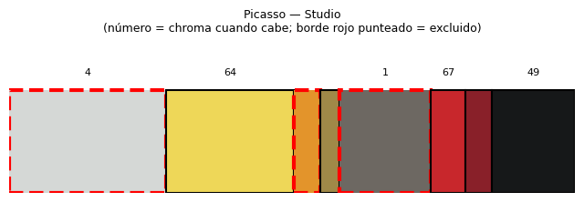

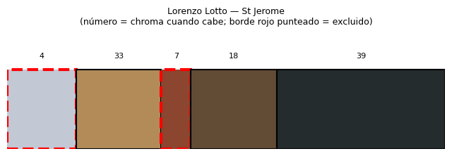

```python
dibujar_muestrario_con_saturacion(
    colores_prueba, centroides_lab_prueba, proporciones_prueba,
    chroma_minimo=10, titulo="Picasso — Studio"
)

dibujar_muestrario_con_saturacion(
    colores_lotto, centroides_lab_lotto, proporciones_lotto,
    chroma_minimo=10, titulo="Lorenzo Lotto — St Jerome"
)
```

#### 10.2.4 Generalizando a las 10 obras

```python
resultados_armonia = []

for nombre in nombres:
    modelo = resultados_por_imagen[nombre]["modelo"]
    pixels = pixels_lab_todas[nombres.index(nombre)]
    centroides_lab = modelo.cluster_centers_
    _, proporciones = generar_muestrario(modelo, pixels)

    plantilla_todos, error_todos = evaluar_armonia(centroides_lab)
    plantilla_sat, error_sat, n_sat = evaluar_armonia_saturados(centroides_lab, chroma_minimo=10)

    autor, titulo = parsear_nombre_archivo(nombre)
    estilo = estilo_por_archivo.get(nombre, "PENDIENTE")

    resultados_armonia.append({
        "titulo": titulo,
        "estilo": estilo,
        "k": resultados_por_imagen[nombre]["k"],
        "colores_saturados": n_sat,
        "plantilla": plantilla_sat if plantilla_sat else "N/A",
        "error_armonia": round(error_sat, 1) if error_sat is not None else None,
    })

df_armonia = pd.DataFrame(resultados_armonia)
df_armonia.sort_values("error_armonia")
```

|  | titulo | estilo | k | colores_saturados | plantilla | error_armonia |
| --- | --- | --- | --- | --- | --- | --- |
| 2 | Lied I 1914 | Simbolismo | 4 | 2 | analoga | 8.2 |
| 8 | St Jerome | Renacimiento temprano | 5 | 3 | analoga | 10.0 |
| 3 | Portrait Of Archibald Campbell 3Rd Duke Of Arg... | Rococó | 4 | 3 | analoga | 12.4 |
| 6 | Evanescence Red 2007 | Minimalismo | 4 | 4 | analoga | 18.4 |
| 9 | Studio | Cubismo | 8 | 5 | analoga | 22.2 |
| 1 | Fumatore | Barroco | 4 | 2 | analoga | 23.8 |
| 0 | Autumn Day | Expresionismo | 5 | 4 | analoga | 27.0 |
| 7 | St John In The Desert | Alto Renacimiento | 4 | 2 | triada | 30.0 |
| 4 | Frog | Pop Art | 8 | 6 | tetrada | 33.2 |
| 5 | The Roofs Of Paris In The Snow 1902 | Puntillismo | 4 | 0 | N/A | NaN |

#### 10.2.5 Sugerencia de color complementario

El análisis anterior solo describe qué tan armoniosa es una paleta ya existente es decir le dice a un diseñador un valor, pero no qué hacer con él. Para que esto tenga valor práctico real para un diseñador, se necesita algo accionable: dado un color de la paleta, sugerir qué color agregar para completar un patrón de armonía específico que podría ser colores complementarios, análogos, tríada entre otros.

```python
def sugerir_color_armonico(color_base_lab, plantilla="complementaria"):
    """Dado un color base (en LAB), calcula qué color(es) agregar para
    completar la plantilla de armonía elegida, manteniendo la misma
    luminosidad y saturación (chroma) del color base — solo cambia el hue."""
    L, a, b = color_base_lab
    chroma = np.sqrt(a**2 + b**2)
    hue_base = np.degrees(np.arctan2(b, a)) % 360

    PLANTILLAS_OFFSETS = {
        "complementaria": [180],
        "analoga": [30, -30],
        "triada": [120, 240],
        "tetrada": [90, 180, 270],
    }

    if plantilla not in PLANTILLAS_OFFSETS:
        raise ValueError(f"Plantilla '{plantilla}' no reconocida. Opciones: {list(PLANTILLAS_OFFSETS.keys())}")

    colores_sugeridos = []
    for offset in PLANTILLAS_OFFSETS[plantilla]:
        hue_nuevo = (hue_base + offset) % 360
        a_nuevo = chroma * np.cos(np.radians(hue_nuevo))
        b_nuevo = chroma * np.sin(np.radians(hue_nuevo))
        colores_sugeridos.append(np.array([L, a_nuevo, b_nuevo]))

    return colores_sugeridos
```

#### 10.2.6 Generalizando la sugerencia a las 10 obras

Se debió aplicar esto a cada color dominante de cada paleta de color de cada obra y se repite la misma limitación de chroma bajo: en paletas donde el color dominante es casi gris u oscuro (Fumatore, St Jerome, Studio), el complementario sugerido resulta casi indistinguible del original un giro de 180° en el hue no genera cambio visual perceptible cuando el chroma es cercano a cero y esto no daría valor alguno a un diseñador.

La función funciona bien cuando se aplica sobre colores con saturación moderada-alta como en Evanescence Red o Autumn Day.

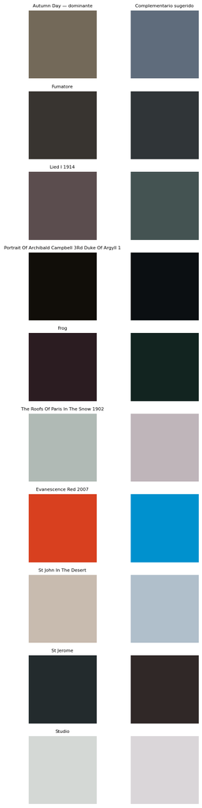

```python
resultados_sugerencias = []

fig, axes = plt.subplots(len(nombres), 2, figsize=(6, 2 * len(nombres)))

for i, nombre in enumerate(nombres):
    modelo = resultados_por_imagen[nombre]["modelo"]
    pixels = pixels_lab_todas[nombres.index(nombre)]
    colores_rgb, proporciones = generar_muestrario(modelo, pixels)

    # El color dominante es el primero en la lista
    idx_dominante = np.argmax(proporciones)
    centroides_lab = modelo.cluster_centers_
    # generar_muestrario ordena por luminosidad
    orden = np.argsort(-centroides_lab[:, 0])
    color_dominante_lab = centroides_lab[orden][idx_dominante]

    sugerido_lab = sugerir_color_armonico(color_dominante_lab, plantilla="complementaria")[0]

    color_dominante_rgb = np.clip(lab2rgb(color_dominante_lab.reshape(1,1,3)).reshape(3), 0, 1)
    sugerido_rgb = np.clip(lab2rgb(sugerido_lab.reshape(1,1,3)).reshape(3), 0, 1)

    autor, titulo = parsear_nombre_archivo(nombre)
    resultados_sugerencias.append({
        "titulo": titulo,
        "color_dominante_rgb": tuple((color_dominante_rgb*255).astype(int)),
        "sugerido_rgb": tuple((sugerido_rgb*255).astype(int)),
    })

    axes[i, 0].imshow([[color_dominante_rgb]])
    axes[i, 0].set_title(f"{titulo} — dominante" if i == 0 else titulo, fontsize=8)
    axes[i, 0].axis('off')

    axes[i, 1].imshow([[sugerido_rgb]])
    axes[i, 1].set_title("Complementario sugerido" if i == 0 else "", fontsize=8)
    axes[i, 1].axis('off')

plt.tight_layout()
plt.show()
```

#### 10.2.7 Qué le aporta esto a un diseñador

Esta sección pasó de responder "¿qué colores tiene la obra?" a responder dos preguntas más útiles que estan mas enfocadas en la labor de diseño: **"¿esta paleta ya es armoniosa según la teoría clásica del color?"** (10.2.1-10.2.4) y, más importante, **"si quiero construir una paleta armoniosa a partir de un color, qué otros colores debería usar?"** (10.2.5-10.2.6). La primera es diagnóstica; la segunda es una herramienta que un diseñador podría usar directamente para generar combinaciones de color a partir de un solo tono de referencia. Con esto vamos un paso mas adelante de sobre como dar aun mas valor que solo extraer una paleta de color

### 10.3 Métricas de evaluación de la paleta: Discriminabilidad

Para que nuestras paletas de color aporten valor, no solo deben mostrar los colores dominantes de las obras evaluadas, los colores de la paleta también deben ser lo suficientemente diferentes entre ellos para que un diseñador o cualquier persona pueda distinguirlos a simple vista.

Esto es especialmente relevante si la paleta se va a usar, por ejemplo, para colorear categorías en un gráfico. Se mide esto calculando la distancia euclidiana en espacio LAB entre cualquier par de colores de la paleta, y nos quedamos con la más pequeña, la misma métrica que ya usa K-means para formar los clusters. Un valor bajo señala que al menos dos colores son casi indistinguibles.

#### 10.3.1 Prueba con una imagen

Pruebo primero con la imagen de referencia (Picasso), antes de generalizar a las 10.

```python
def evaluar_discriminabilidad(centroides_lab):
    """Mide qué tan fácil es distinguir cada color de la paleta de los demás,
    calculando la distancia euclidiana mínima en espacio LAB entre cualquier
    par de colores la misma métrica que ya usa K-means para formar los
    clusters, manteniendo consistencia con el resto del pipeline."""
    n = len(centroides_lab)
    distancias = []
    pares = []
    for i in range(n):
        for j in range(i+1, n):
            d = float(np.linalg.norm(centroides_lab[i] - centroides_lab[j]))
            distancias.append(d)
            pares.append((i, j))

    idx_min = int(np.argmin(distancias))
    return {
        "distancia_minima": distancias[idx_min],
        "distancia_promedio": float(np.mean(distancias)),
        "par_mas_parecido": pares[idx_min],
    }
```

```python
resultado_disc = evaluar_discriminabilidad(mejor["modelo"].cluster_centers_)

print(f"Distancia mínima entre colores: {resultado_disc['distancia_minima']:.1f}")
print(f"Distancia promedio: {resultado_disc['distancia_promedio']:.1f}")
print(f"Par más parecido (índices de cluster): {resultado_disc['par_mas_parecido']}")

if resultado_disc['distancia_minima'] < 10:
    print("Hay al menos dos colores difíciles de distinguir entre sí")
else:
    print("Todos los colores son razonablemente distinguibles")
```

```
Distancia mínima entre colores: 27.4
Distancia promedio: 61.1
Par más parecido (índices de cluster): (3, 7)
Todos los colores son razonablemente distinguibles
```

#### 10.3.2 Generalización a las 10 imágenes

Aplico `evaluar_discriminabilidad()` a la paleta de cada obra, para ver si alguna presenta colores demasiado parecidos entre sí.

```python
resultados_discriminabilidad = []

for nombre in nombres:
    modelo = resultados_por_imagen[nombre]["modelo"]
    resultado = evaluar_discriminabilidad(modelo.cluster_centers_)

    autor, titulo = parsear_nombre_archivo(nombre)
    resultados_discriminabilidad.append({
        "titulo": titulo,
        "k": resultados_por_imagen[nombre]["k"],
        "distancia_minima": round(resultado["distancia_minima"], 1),
        "distancia_promedio": round(resultado["distancia_promedio"], 1),
        "alerta": "colores parecidos" if resultado["distancia_minima"] < 10 else "OK",
    })

df_discriminabilidad = pd.DataFrame(resultados_discriminabilidad)
df_discriminabilidad.sort_values("distancia_minima")
```

[output not shown]

- si va a usar la paleta de Fumatore para, por ejemplo, colorear categorías en un gráfico, debería revisar y posiblemente fusionar o reemplazar el par de colores más parecido antes de usarla.

#### 10.3.3 Verificación visual del caso con alerta

Se confirma visualmente cuáles son los dos colores de Fumatore que casi se confunden entre sí.

```
Color 1: RGB(np.int64(56), np.int64(52), np.int64(48))
Color 3: RGB(np.int64(73), np.int64(62), np.int64(53))
```

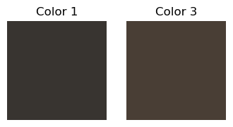

```python
modelo_fumatore = resultados_por_imagen[nombres[nombres.index("adriaen-brouwer_fumatore.jpg")]]["modelo"]
resultado_fumatore = evaluar_discriminabilidad(modelo_fumatore.cluster_centers_)

i, j = resultado_fumatore["par_mas_parecido"]
centroides_rgb_fumatore = np.clip(lab2rgb(modelo_fumatore.cluster_centers_.reshape(-1,1,3)).reshape(-1,3), 0, 1)

print(f"Color {i}: RGB{tuple((centroides_rgb_fumatore[i]*255).astype(int))}")
print(f"Color {j}: RGB{tuple((centroides_rgb_fumatore[j]*255).astype(int))}")

fig, axes = plt.subplots(1, 2, figsize=(4, 2))
axes[0].imshow([[centroides_rgb_fumatore[i]]])
axes[0].set_title(f"Color {i}")
axes[0].axis('off')
axes[1].imshow([[centroides_rgb_fumatore[j]]])
axes[1].set_title(f"Color {j}")
axes[1].axis('off')
plt.show()
```

#### 10.3.4 Cierre

Con esta métrica logramos complementar el análisis de armonía (10.2) que realizamos anteriormente, es decir que: mientras que armonía evalúa si los colores siguen un patrón estético clásico, discriminabilidad evalúa si son suficientemente distintos como para ser útiles en un contexto donde cada color debe representar algo distinguible.

Es una métrica directamente accionable:

-un valor bajo le indica al diseñador exactamente qué par de colores de la paleta debería revisar o eliminar algo que el análisis de armonía, por sí solo, no ofrece.